# Subsample coefficient of variation

Joyce Hsiao

2015-10-24

**Last updated:** 2015-10-26

**Code version:** f61cb0a74f4310b4c35dd802d9c73ec0e9eff230

## Objective

Need to repeat the analysis across a range of subsample sizes.

## Set up

```r
library("data.table")
library("dplyr")
library("limma")
library("edgeR")
library("ggplot2")
library("grid")
theme_set(theme_bw(base_size = 12))
source("functions.R")
```

## Prepare data

Input annotation of only QC-filtered single cells. Remove NA19098.r2

```r
anno_qc <- read.table("../data/annotation-filter.txt", header = TRUE,
                   stringsAsFactors = FALSE)
is_include <- anno_qc$batch != "NA19098.r2"
anno_qc_filter <- anno_qc[which(is_include), ]
```

Import endogeneous gene molecule counts that are QC-filtered, CPM-normalized, ERCC-normalized, and also processed to remove unwanted variation from batch effet. ERCC genes are removed from this file.

```r
molecules_ENSG <- read.table("../data/molecules-final.txt", header = TRUE, stringsAsFactors = FALSE)
molecules_ENSG <- molecules_ENSG[ , is_include]
```

Input moleclule counts before log2 CPM transformation. This file is used to compute percent zero-count cells per sample.

```r
molecules_sparse <- read.table("../data/molecules-filter.txt", header = TRUE, stringsAsFactors = FALSE)

molecules_sparse <- molecules_sparse[grep("ENSG", rownames(molecules_sparse)), ]
stopifnot( all.equal(rownames(molecules_ENSG), rownames(molecules_sparse)) )
```

## Compute normalized CV

```r
source("../code/cv-functions.r")

# compute_cv() takes log2 counts as input
ENSG_cv <- compute_cv(counts = molecules_ENSG,
                           anno = anno_qc_filter)

ENSG_cv_adj <- normalize_cv(batch_cv = ENSG_cv,
                                 counts = molecules_ENSG,
                                 anno = anno_qc_filter)
```

## Compute normalied CV based on subsamples

*Three subsamples for each individual, 20 cells per sample

```r
source("../code/cv-functions.r")

subsample_obj <- make_subsample(counts = molecules_ENSG,
                                anno = anno_qc_filter,
                                subsample_size = 20,
                                number_subsample = 3)

subsample_cv <- compute_cv(counts = subsample_obj$counts_subsample,
                           anno = subsample_obj$anno_subsample)

subsample_cv_adj <- normalize_cv(batch_cv = subsample_cv,
                                 counts = subsample_obj$counts_subsample,
                                 anno = subsample_obj$anno_subsample)
```

Prepare data.frames.

```r
df_adj <- do.call(rbind, subsample_cv_adj)
df_raw <- do.call(rbind, ENSG_cv_adj)

df_adj$ENSG <- sapply(strsplit(rownames(df_adj), fix = TRUE, split = "."), "[[", 3)
df_raw$ENSG <- sapply(strsplit(rownames(df_raw), fix = TRUE, split = "."), "[[", 3)

df_adj[df_adj$ENSG == "ENSG00000237683", ]
```

```
                               mean        sd        cv individual
NA19098r.1.ENSG00000237683 12.79108  9.927976 0.7761642    NA19098
NA19098r.2.ENSG00000237683 13.56058 15.509013 1.1436836    NA19098
NA19098r.3.ENSG00000237683 10.68175 15.417189 1.4433204    NA19098
NA19101r.1.ENSG00000237683 17.60737 20.986356 1.1919077    NA19101
NA19101r.2.ENSG00000237683 19.17407 21.069357 1.0988461    NA19101
NA19101r.3.ENSG00000237683 29.59335 42.977614 1.4522729    NA19101
NA19239r.1.ENSG00000237683 11.99118 10.081523 0.8407451    NA19239
NA19239r.2.ENSG00000237683 13.68649 17.775621 1.2987715    NA19239
NA19239r.3.ENSG00000237683 15.65900 17.359454 1.1085928    NA19239
                           replicate      batch log10cv2_adj
NA19098r.1.ENSG00000237683       r.1 NA19098r.1  -0.48174860
NA19098r.2.ENSG00000237683       r.2 NA19098r.2  -0.14504401
NA19098r.3.ENSG00000237683       r.3 NA19098r.3   0.05706975
NA19101r.1.ENSG00000237683       r.1 NA19101r.1  -0.10917054
NA19101r.2.ENSG00000237683       r.2 NA19101r.2  -0.17978202
NA19101r.3.ENSG00000237683       r.3 NA19101r.3   0.06244068
NA19239r.1.ENSG00000237683       r.1 NA19239r.1  -0.41232709
NA19239r.2.ENSG00000237683       r.2 NA19239r.2  -0.03459025
NA19239r.3.ENSG00000237683       r.3 NA19239r.3  -0.17211167
                                      ENSG
NA19098r.1.ENSG00000237683 ENSG00000237683
NA19098r.2.ENSG00000237683 ENSG00000237683
NA19098r.3.ENSG00000237683 ENSG00000237683
NA19101r.1.ENSG00000237683 ENSG00000237683
NA19101r.2.ENSG00000237683 ENSG00000237683
NA19101r.3.ENSG00000237683 ENSG00000237683
NA19239r.1.ENSG00000237683 ENSG00000237683
NA19239r.2.ENSG00000237683 ENSG00000237683
NA19239r.3.ENSG00000237683 ENSG00000237683
```

```r
df_raw[df_raw$ENSG == "ENSG00000237683", ]
```

```
                               mean       sd        cv individual
NA19098.r1.ENSG00000237683 11.72203 13.99212 1.1936607    NA19098
NA19098.r3.ENSG00000237683 10.42064 14.54474 1.3957627    NA19098
NA19101.r1.ENSG00000237683 26.76684 40.01791 1.4950552    NA19101
NA19101.r2.ENSG00000237683 21.24132 28.10910 1.3233216    NA19101
NA19101.r3.ENSG00000237683 21.85125 25.25416 1.1557307    NA19101
NA19239.r1.ENSG00000237683 18.40559 23.30683 1.2662910    NA19239
NA19239.r2.ENSG00000237683 19.22832 28.41578 1.4778093    NA19239
NA19239.r3.ENSG00000237683 13.26431 11.88992 0.8963841    NA19239
                           replicate      batch log10cv2_adj
NA19098.r1.ENSG00000237683        r1 NA19098.r1  -0.17210751
NA19098.r3.ENSG00000237683        r3 NA19098.r3  -0.03624615
NA19101.r1.ENSG00000237683        r1 NA19101.r1   0.02344512
NA19101.r2.ENSG00000237683        r2 NA19101.r2  -0.08253853
NA19101.r3.ENSG00000237683        r3 NA19101.r3  -0.20015600
NA19239.r1.ENSG00000237683        r1 NA19239.r1  -0.12080227
NA19239.r2.ENSG00000237683        r2 NA19239.r2   0.01336747
NA19239.r3.ENSG00000237683        r3 NA19239.r3  -0.42088098
                                      ENSG
NA19098.r1.ENSG00000237683 ENSG00000237683
NA19098.r3.ENSG00000237683 ENSG00000237683
NA19101.r1.ENSG00000237683 ENSG00000237683
NA19101.r2.ENSG00000237683 ENSG00000237683
NA19101.r3.ENSG00000237683 ENSG00000237683
NA19239.r1.ENSG00000237683 ENSG00000237683
NA19239.r2.ENSG00000237683 ENSG00000237683
NA19239.r3.ENSG00000237683 ENSG00000237683
```

## limma

```r
library(limma)

number_batch <- length(unique(subsample_obj$anno_subsample$batch))
df_limma <- matrix(df_adj$log10cv2_adj,
                   nrow = nrow(subsample_obj$counts_subsample),
                   ncol = number_batch, byrow = FALSE)
individual <- factor(matrix(df_adj$individual,
                           nrow = nrow(subsample_obj$counts_subsample),
                           ncol = number_batch, byrow = FALSE)[1,] )

# limma fit
fit_limma <- lmFit(df_limma,
                   design = model.matrix(~individual))
# empricial bayes
fit_limma <- eBayes(fit_limma)
```

Histogram of p-value.

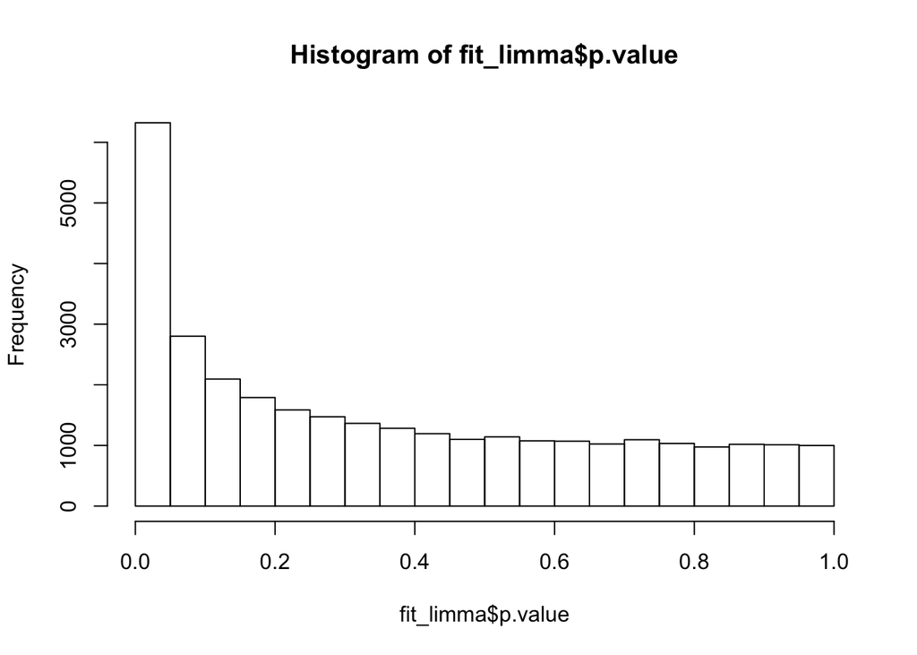

```r
hist(fit_limma$p.value)
```

False discovery control adjustment.

```r
F.p.adj <- p.adjust(fit_limma$F.p.value, method = "fdr")
```

Cutoffs

```r
df_cuts <- data.frame(cuts = c(.001, .01, .05, .1, .15, .2))
df_cuts$sig_count <- sapply(1:6, function(per_cut) {
                    sum(F.p.adj < df_cuts$cuts[per_cut] )
                    })
df_cuts
```

```
   cuts sig_count
1 0.001        10
2 0.010       212
3 0.050      1363
4 0.100      2607
5 0.150      3733
6 0.200      4513
```

False discovery control adjutment.

```r
F.p.adj <- p.adjust(fit_limma$F.p.value, method = "fdr")
```

## Investigate…

Our naive analysis seems to pick up genes with different density between individuals.

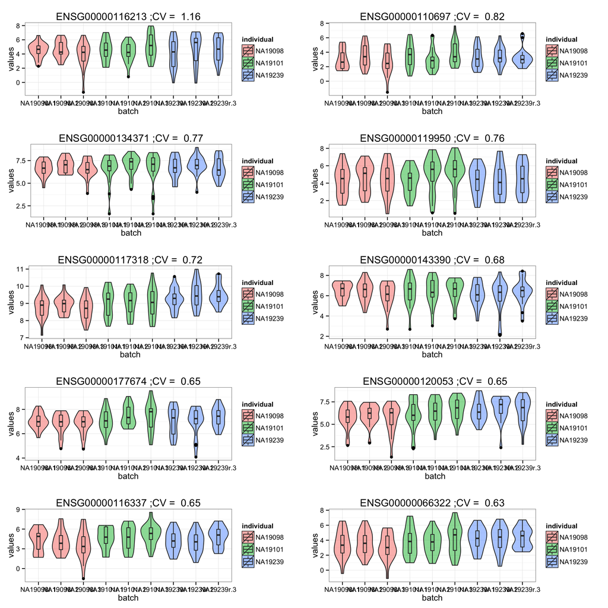

```r
library(gridExtra)
order_high_cv <- order(df_adj[F.p.adj < .01, ]$log10cv2_adj, decreasing = TRUE)
high_plots <- lapply(1:10, function(i) {
  ind <- order_high_cv[i]
  ggplot(data.frame(values = unlist(subsample_obj$counts_subsample[ind, ]),
                    individual = factor(subsample_obj$anno_subsample$individual),
                    replicate = factor(subsample_obj$anno_subsample$replicate),
                    batch = factor(subsample_obj$anno_subsample$batch), check.rows = F),
         aes(x = batch, y = values, fill = individual)) +
    geom_violin(alpha = .5) +
    geom_boxplot(alpha = .1, width = .2) +
    ggtitle(paste(rownames(subsample_obj$counts_subsample)[ind],
                  ";CV = ", round(df_adj[F.p.adj < .01, ]$log10cv2_adj[ind], 2) ) )
})
grid.arrange(grobs = high_plots, ncol = 2)
```

## PCA

Prepare a matrix of normalized CVs.

```r
df_cv <- matrix(df_adj$log10cv2_adj,
                   nrow = nrow(subsample_obj$counts_subsample),
                   ncol = number_batch, byrow = FALSE)

prcomp_cv <- prcomp(t(df_cv) %*% df_cv)

library(qtlcharts)
iplot(prcomp_cv$x[,1], prcomp_cv$x[,2],
      as.numeric(as.factor( unique(subsample_obj$anno_subsample$batch) )),
      unique(subsample_obj$anno_subsample$batch) )
```

[interactive chart not shown]